# Final Project: Covid’s effect on Danes’ Television Consumption

Karoline Støjberg Sejersen

08 Januar 2022

```r
library(tidyverse)
```

```r
library(ggplot2)
library(dplyr)
library(readr)
```

# About the data

The data has been collected from Danmarks Statistik and Our World in Data (WHO), and is free to use. It is present in my GitHub https://github.com/Digital-Methods-HASS/AU681035_Sejersen_Karoline

- Link for Danmarks Statistik data: https://www.statistikbanken.dk/KVUH2KA.
- Link for WHO data: https://ourworldindata.org/grapher/share-of-adults-who-are-overweight

# License

Creative Commons Legal Code - CC0 1.0 Universal (CC0 1.0)

# Data processing

### Loading data about TV-shows and movies

I am reading in the data from Danmarks Statistik about the weekly consumption of TV-shows and movies. The data has been made clean by me. However, I do have a problem because the Excel-sheets I create myself can only be separated by semicolon instead of comma. Therefore, I use the function read_delim() instead of read_csv(), so I can change the delimiter to semicolon.

```r
tvshows_danes <- read_delim("data/tvshows_danes.csv",
    delim = ";", escape_double = FALSE, trim_ws = TRUE)
head(tvshows_danes)
```

```
## # A tibble: 3 × 11
##    year no_activity_percent `1_2_times_a_wee… `3_4_times_a_wee… nearly_daily_pe…
##   <dbl>               <dbl>             <dbl>             <dbl>            <dbl>
## 1  2018                  31                28                15               19
## 2  2019                  27                26                15               23
## 3  2020                  22                29                17               24
## # … with 6 more variables: multiple_times_daily_percent <dbl>,
## #   no_activity_danes <dbl>, 1_2_times_weekly_danes <dbl>,
## #   3_4_times_weekly_danes <dbl>, nearly_daily_danes <dbl>,
## #   multiple_times_daily_danes <dbl>
```

```r
movies_danes <- movies <- read_delim("data/movies_danes.csv", delim = ";",
    escape_double = FALSE, trim_ws = TRUE)
head(movies_danes)
```

```
## # A tibble: 3 × 11
##    year no_activity_percent `1_2_days_a_week… `3_4_days_a_week… nearly_daily_pe…
##   <dbl>               <dbl>             <dbl>             <dbl>            <dbl>
## 1  2018                  27                40                17               13
## 2  2019                  27                38                16               15
## 3  2020                  25                39                16               16
## # … with 6 more variables: multiple_times_daily_percent <dbl>,
## #   no_activity_danes <dbl>, 1_2_days_weekly_danes <dbl>,
## #   3_4_days_weekly_danes <dbl>, nearly_daily_danes <dbl>,
## #   multiple_times_daily_danes <dbl>
```

### Plotting the data for TV-shows and movies

Now I plot the data by using a data frame (See research paper for more information about the data frame).

```r
df_tvshows <-  tvshows_danes %>%
  data.frame(year = c(2018, 2019, 2020),
                `a. No activity` = c(tvshows_danes$no_activity_danes),
                `b. 1-2 times weekly` = c(tvshows_danes$`1_2_times_weekly_danes`),
                `c. 3-4 times weekly` = c(tvshows_danes$`3_4_times_weekly_danes`),
                `d. Nearly daily` = c(tvshows_danes$nearly_daily_danes),
                `e. Multiple times daily` = c(tvshows_danes$multiple_times_daily_danes)) %>%
        pivot_longer(cols = 7:11, names_to = "indicatorTV", values_to = "valuesTV")
```

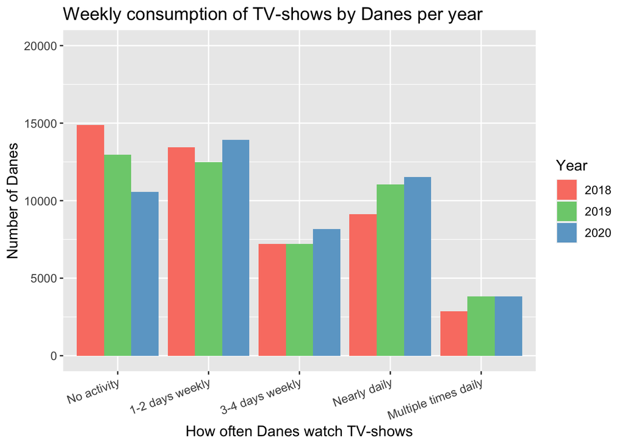

```r
df_tvshows %>%
  ggplot(aes(x = indicatorTV, y = valuesTV, fill = as.factor(year))) +
  geom_bar(stat = "identity", position = "dodge") +
  labs(title="Weekly consumption of TV-shows by Danes per year",
         x="How often Danes watch TV-shows",
         y="Number of Danes") +
  theme(text = element_text(size = 12), axis.text.x = element_text(angle = 20, vjust = 1, hjust = 1)) +
  ylim(0,20000) +
  scale_fill_manual('Year', values = c('salmon','palegreen3','skyblue3')) +
  scale_x_discrete(limits=c("no_activity_danes","X1_2_times_weekly_danes","X3_4_times_weekly_danes","nearly_daily_danes","multiple_times_daily_danes"), labels=c("no_activity_danes" = "No activity", "X1_2_times_weekly_danes" = "1-2 days weekly", "X3_4_times_weekly_danes" = "3-4 days weekly","nearly_daily_danes" = "Nearly daily","multiple_times_daily_danes" = "Multiple times daily"))
```

```r
df_movies <-  movies_danes %>%
  data.frame(year = c(2018, 2019, 2020),
                `a. No activity`= c(movies_danes$no_activity_danes),
                `b. 1-2 days weekly` = c(movies_danes$`1_2_days_weekly_danes`),
                `c. 3-4 days weekly` = c(movies_danes$`3_4_days_weekly_danes`),
                `d. Nearly daily`= c(movies_danes$nearly_daily_danes),
                `e. Multiple times daily` = c(movies_danes$multiple_times_daily_danes)) %>%
        pivot_longer(cols = 7:11, names_to = "indicatorM", values_to = "valuesM")
```

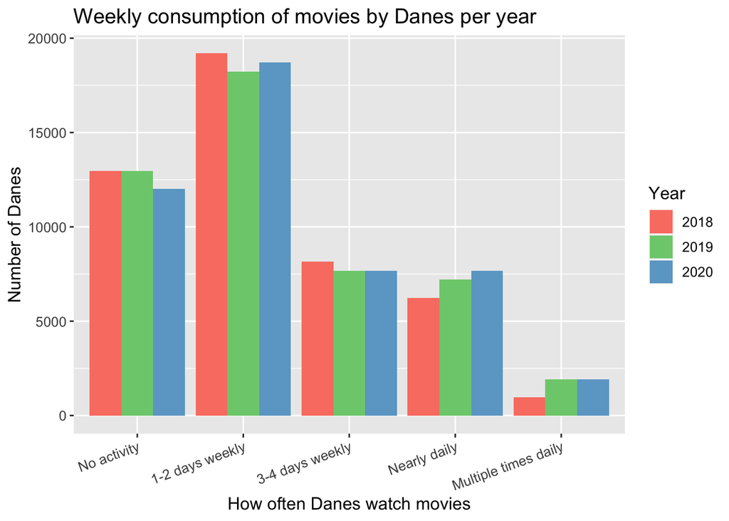

```r
df_movies %>%
  ggplot(aes(x = indicatorM, y = valuesM, fill = as.factor(year))) +
  geom_bar(stat = "identity", position = "dodge") +
  labs(title="Weekly consumption of movies by Danes per year",
         x="How often Danes watch movies",
         y="Number of Danes") +
  theme(text = element_text(size = 12), axis.text.x = element_text(angle = 20, vjust = 1, hjust = 1)) +
  scale_fill_manual('Year', values = c('salmon','palegreen3','skyblue3')) +
  scale_x_discrete(limits=c("no_activity_danes","X1_2_days_weekly_danes","X3_4_days_weekly_danes","nearly_daily_danes","multiple_times_daily_danes"),labels=c("multiple_times_daily_danes" = "Multiple times daily", "nearly_daily_danes" = "Nearly daily", "no_activity_danes" = "No activity", "X1_2_days_weekly_danes" = "1-2 days weekly", "X3_4_days_weekly_danes" = "3-4 days weekly"))
```

### Loading and plotting data for overweight/obesity in Denmark

This data has been uploaded by Our World in Data but is from WHO. This data was clean and I did not have any trouble with using the read_csv()-function.

```r
overweight_adult_danes_1975_2016 <- read_csv("data/overweight_adult_danes_1975_2016.csv")
head(overweight_adult_danes_1975_2016)
```

```
## # A tibble: 6 × 4
##   country landcode  year percent_overweight_adult_danes
##   <chr>   <chr>    <dbl>                          <dbl>
## 1 Denmark DNK       1975                           37.4
## 2 Denmark DNK       1976                           38
## 3 Denmark DNK       1977                           38.7
## 4 Denmark DNK       1978                           39.3
## 5 Denmark DNK       1979                           39.9
## 6 Denmark DNK       1980                           40.5
```

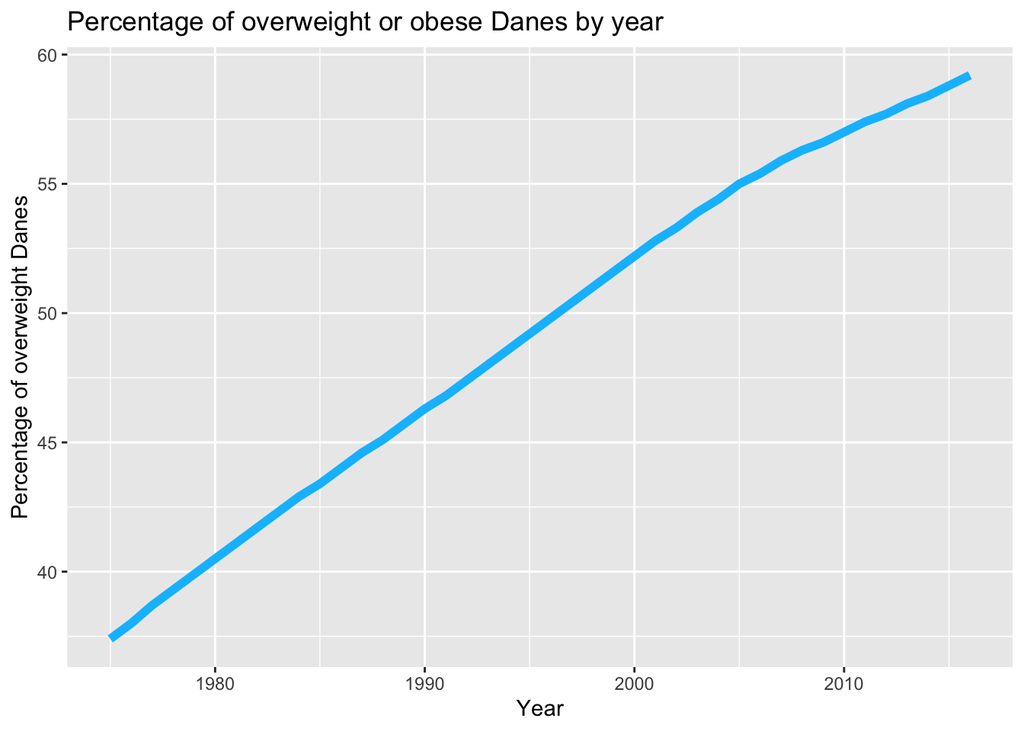

```r
overweight_adult_danes_1975_2016 %>%
  ggplot(aes(x= overweight_adult_danes_1975_2016$year, y = overweight_adult_danes_1975_2016$percent_overweight_adult_danes)) +
  geom_line(color="deepskyblue1", size=2) +
    labs(title="Percentage of overweight or obese Danes by year",
         x="Year",
         y="Percentage of overweight Danes")
```

### Loading data for consumption of TV-shows and movies according to age

Again, I have used data from Danmarks Statistik and face the same problems with the read_csv()-function.

```r
age_tvshows <- read_delim("data/age_tvshows.csv",
                        delim = ";", escape_double = FALSE, trim_ws = TRUE)
head(age_tvshows)
```

```
## # A tibble: 6 × 9
##    year amount           tvshows_16_24 tvshows_25_34 tvshows_35_44 tvshows_45_54
##   <dbl> <chr>                    <dbl>         <dbl>         <dbl>         <dbl>
## 1  2018 e. Multiple tim…            16            11             6             4
## 2  2018 d. Nearly daily             31            29            19            16
## 3  2018 c. 3-4 days wee…            16            17            18            16
## 4  2018 b. 1-2 days wee…            19            22            27            30
## 5  2018 a. No activity              18            21            29            34
## 6  2019 e. Multiple tim…            21            13             8             5
## # … with 3 more variables: tvshows_55_64 <dbl>, tvshows_65_74 <dbl>,
## #   tvshows_75_over <dbl>
```

```r
age_movies <- read_delim("data/age_movies.csv",
                        delim = ";", escape_double = FALSE, trim_ws = TRUE)
head(age_movies)
```

```
## # A tibble: 6 × 9
##    year amount  movies_16_24 movies_25_34 movies_35_44 movies_45_54 movies_55_64
##   <dbl> <chr>          <dbl>        <dbl>        <dbl>        <dbl>        <dbl>
## 1  2018 e. Mul…            2            3            2            2            2
## 2  2018 d. Nea…           14           12           10           14           13
## 3  2018 c. 3-4…           21           14           16           18           18
## 4  2018 b. 1-2…           42           43           46           41           39
## 5  2018 a. No …           21           28           26           24           27
## 6  2019 e. Mul…            6            4            4            3            3
## # … with 2 more variables: movies_65_74 <dbl>, movies_75_over <dbl>
```

### Plotting weekly consumption of TV-shows according to age

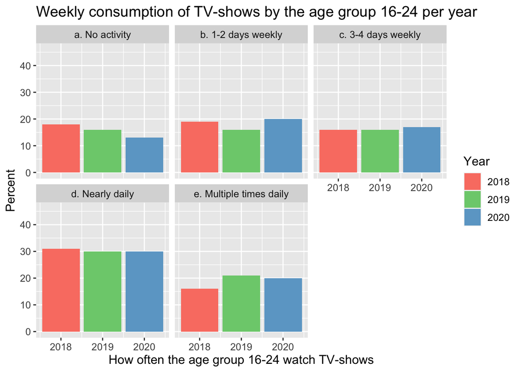

```r
age_tvshows %>%
  ggplot(aes(x = year, y = tvshows_16_24, fill = as.factor(year))) +
  geom_bar(stat = "identity", position = "dodge") +
  labs(title="Weekly consumption of TV-shows by the age group 16-24 per year",
       x="How often the age group 16-24 watch TV-shows",
       y="Percent") +
  theme(text = element_text(size = 12))+
  facet_wrap(~ age_tvshows$amount) +
  ylim(0,46) +
  scale_fill_manual('Year', values = c('salmon','palegreen3','skyblue3'))
```

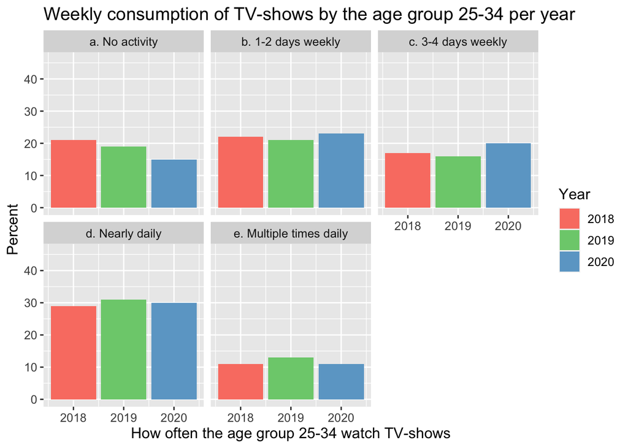

```r
age_tvshows %>%
  ggplot(aes(x = year, y = tvshows_25_34, fill = as.factor(year))) +
  geom_bar(stat = "identity", position = "dodge") +
  labs(title="Weekly consumption of TV-shows by the age group 25-34 per year",
       x="How often the age group 25-34 watch TV-shows",
       y="Percent") +
  theme(text = element_text(size = 12))+
  facet_wrap(~ age_tvshows$amount) +
  ylim(0,46) +
  scale_fill_manual('Year', values = c('salmon','palegreen3','skyblue3'))
```

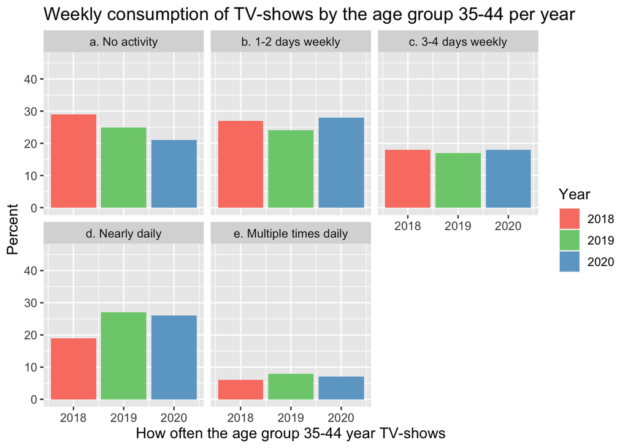

```r
age_tvshows %>%
  ggplot(aes(x = year, y = tvshows_35_44, fill = as.factor(year))) +
  geom_bar(stat = "identity", position = "dodge") +
  labs(title="Weekly consumption of TV-shows by the age group 35-44 per year",
       x="How often the age group 35-44 year TV-shows",
       y="Percent") +
  theme(text = element_text(size = 12))+
  facet_wrap(~ age_tvshows$amount) +
  ylim(0,46) +
  scale_fill_manual('Year', values = c('salmon','palegreen3','skyblue3'))
```

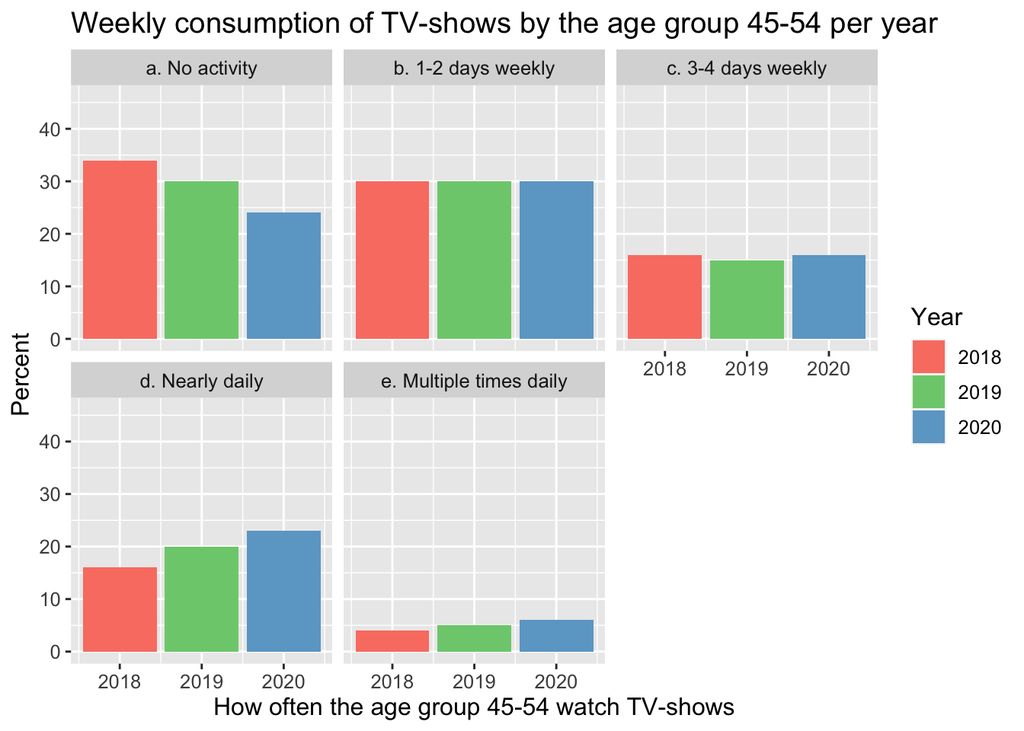

```r
age_tvshows %>%
  ggplot(aes(x = year, y = tvshows_45_54, fill = as.factor(year))) +
  geom_bar(stat = "identity", position = "dodge") +
  labs(title="Weekly consumption of TV-shows by the age group 45-54 per year",
       x="How often the age group 45-54 watch TV-shows",
       y="Percent") +
  theme(text = element_text(size = 12))+
  facet_wrap(~ age_tvshows$amount) +
  ylim(0,46) +
  scale_fill_manual('Year', values = c('salmon','palegreen3','skyblue3'))
```

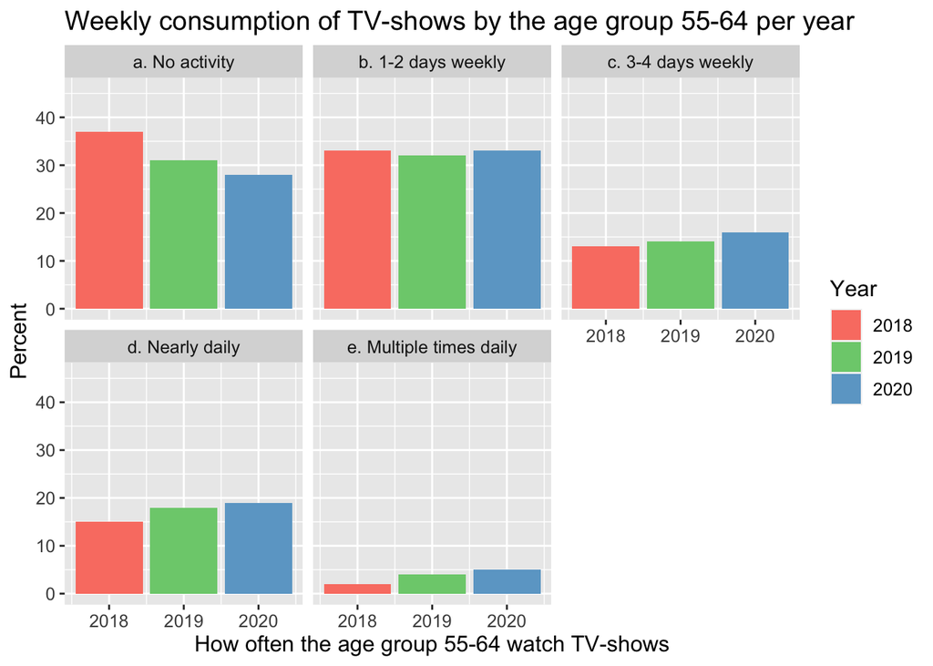

```r
age_tvshows %>%
  ggplot(aes(x = year, y = tvshows_55_64, fill = as.factor(year))) +
  geom_bar(stat = "identity", position = "dodge") +
  labs(title="Weekly consumption of TV-shows by the age group 55-64 per year",
       x="How often the age group 55-64 watch TV-shows",
       y="Percent") +
  theme(text = element_text(size = 12))+
  facet_wrap(~ age_tvshows$amount) +
  ylim(0,46) +
  scale_fill_manual('Year', values = c('salmon','palegreen3','skyblue3'))
```

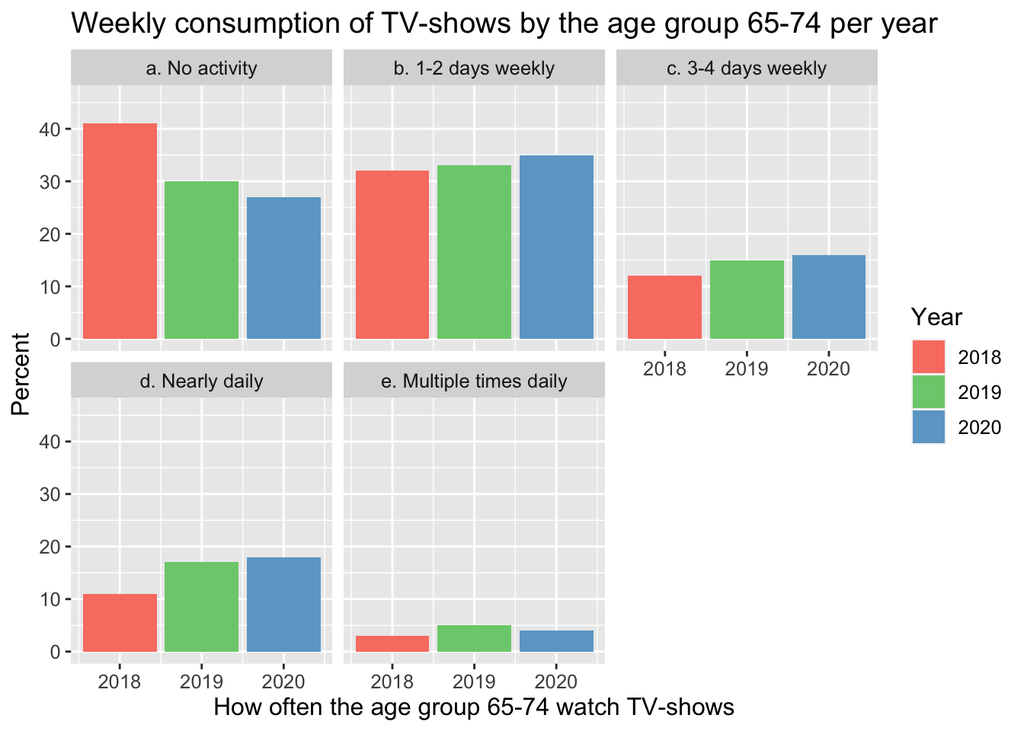

```r
age_tvshows %>%
  ggplot(aes(x = year, y = tvshows_65_74, fill = as.factor(year))) +
  geom_bar(stat = "identity", position = "dodge") +
  labs(title="Weekly consumption of TV-shows by the age group 65-74 per year",
       x="How often the age group 65-74 watch TV-shows",
       y="Percent") +
  theme(text = element_text(size = 12))+
  facet_wrap(~ age_tvshows$amount) +
  ylim(0,46) +
  scale_fill_manual('Year', values = c('salmon','palegreen3','skyblue3'))
```

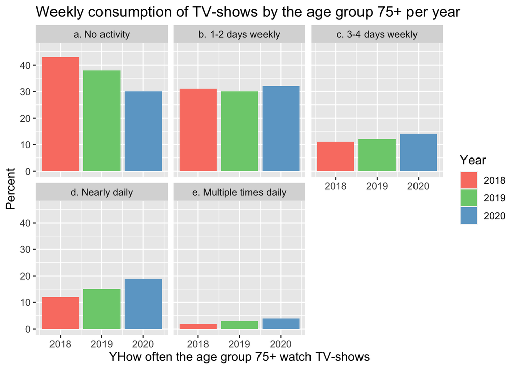

```r
age_tvshows %>%
  ggplot(aes(x = year, y = tvshows_75_over, fill = as.factor(year))) +
  geom_bar(stat = "identity", position = "dodge") +
  labs(title="Weekly consumption of TV-shows by the age group 75+ per year",
       x="YHow often the age group 75+ watch TV-shows",
       y="Percent") +
  theme(text = element_text(size = 12))+
  facet_wrap(~ age_tvshows$amount) +
  ylim(0,46) +
  scale_fill_manual('Year', values = c('salmon','palegreen3','skyblue3'))
```

### Plotting weekly consumption of movies according to age

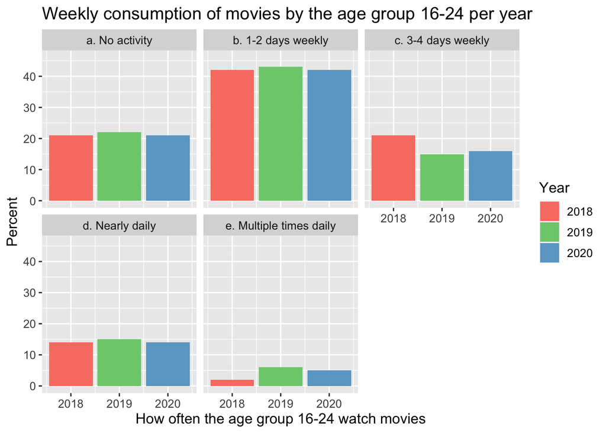

```r
age_movies %>%
  ggplot(aes(x = year, y = movies_16_24, fill = as.factor(year))) +
  geom_bar(stat = "identity", position = "dodge") +
  labs(title="Weekly consumption of movies by the age group 16-24 per year",
       x="How often the age group 16-24 watch movies",
       y="Percent") +
  theme(text = element_text(size = 12))+
  facet_wrap(~ age_movies$amount) +
  ylim(0,46) +
  scale_fill_manual('Year', values = c('salmon','palegreen3','skyblue3'))
```

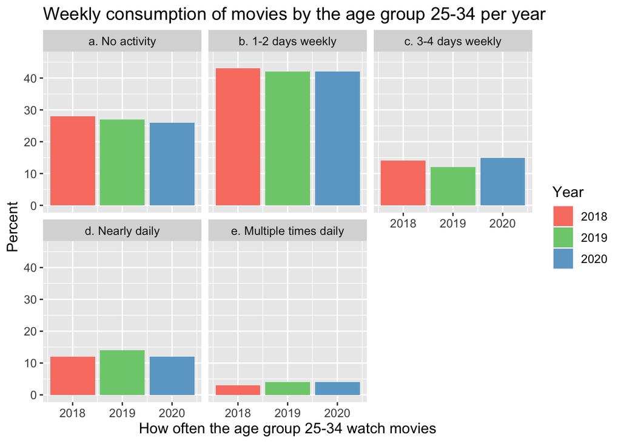

```r
age_movies %>%
  ggplot(aes(x = year, y = movies_25_34, fill = as.factor(year))) +
  geom_bar(stat = "identity", position = "dodge") +
  labs(title="Weekly consumption of movies by the age group 25-34 per year",
       x="How often the age group 25-34 watch movies",
       y="Percent") +
  theme(text = element_text(size = 12))+
  facet_wrap(~ age_movies$amount) +
  ylim(0,46) +
  scale_fill_manual('Year', values = c('salmon','palegreen3','skyblue3'))
```

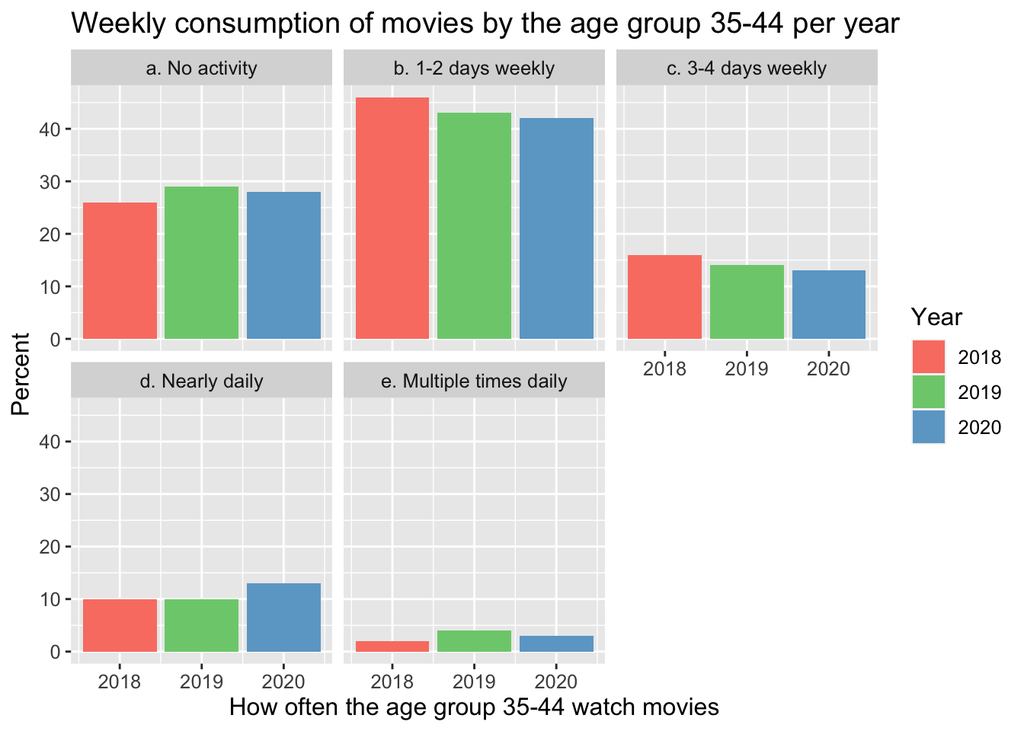

```r
age_movies %>%
  ggplot(aes(x = year, y = movies_35_44, fill = as.factor(year))) +
  geom_bar(stat = "identity", position = "dodge") +
  labs(title="Weekly consumption of movies by the age group 35-44 per year",
       x="How often the age group 35-44 watch movies",
       y="Percent") +
  theme(text = element_text(size = 12))+
  facet_wrap(~ age_movies$amount) +
  ylim(0,46) +
  scale_fill_manual('Year', values = c('salmon','palegreen3','skyblue3'))
```

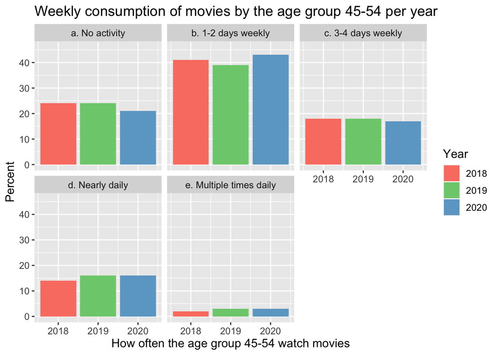

```r
age_movies %>%
  ggplot(aes(x = year, y = movies_45_54, fill = as.factor(year))) +
  geom_bar(stat = "identity", position = "dodge") +
  labs(title="Weekly consumption of movies by the age group 45-54 per year",
       x="How often the age group 45-54 watch movies",
       y="Percent") +
  theme(text = element_text(size = 12))+
  facet_wrap(~ age_movies$amount) +
  ylim(0,46) +
  scale_fill_manual('Year', values = c('salmon','palegreen3','skyblue3'))
```

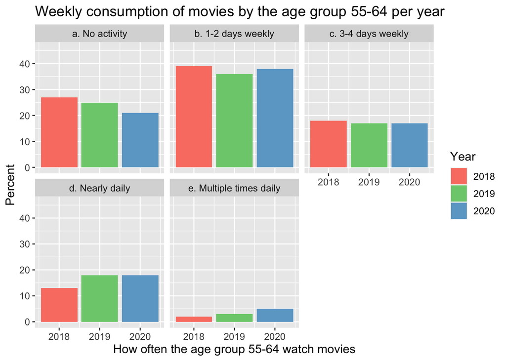

```r
age_movies %>%
  ggplot(aes(x = year, y = movies_55_64, fill = as.factor(year))) +
  geom_bar(stat = "identity", position = "dodge") +
  labs(title="Weekly consumption of movies by the age group 55-64 per year",
       x="How often the age group 55-64 watch movies",
       y="Percent") +
  theme(text = element_text(size = 12))+
  facet_wrap(~ age_movies$amount) +
  ylim(0,46) +
  scale_fill_manual('Year', values = c('salmon','palegreen3','skyblue3'))
```

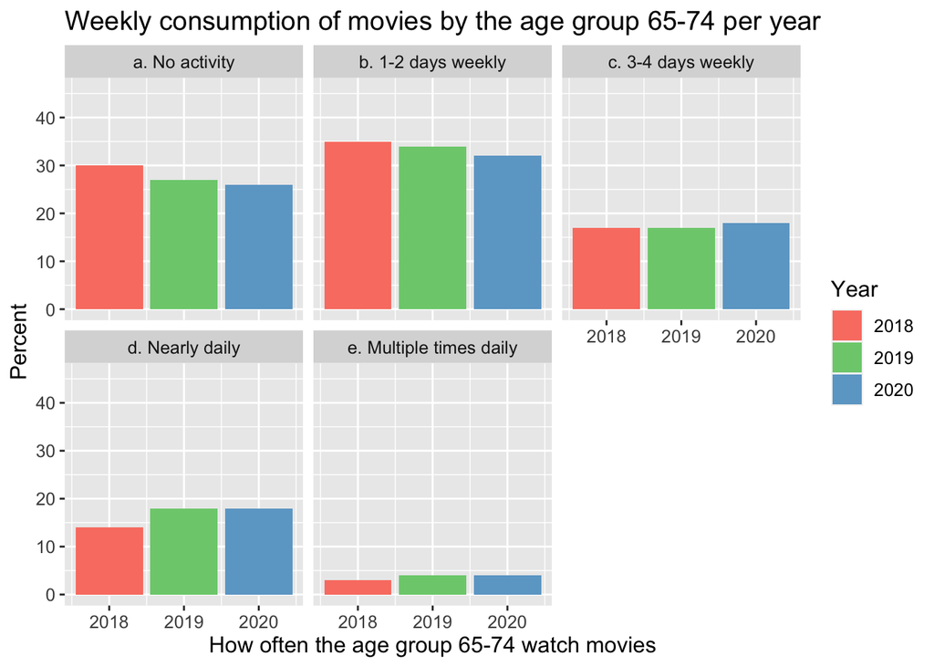

```r
age_movies %>%
  ggplot(aes(x = year, y = movies_65_74, fill = as.factor(year))) +
  geom_bar(stat = "identity", position = "dodge") +
  labs(title="Weekly consumption of movies by the age group 65-74 per year",
       x="How often the age group 65-74 watch movies",
       y="Percent") +
  theme(text = element_text(size = 12))+
  facet_wrap(~ age_movies$amount) +
  ylim(0,46) +
  scale_fill_manual('Year', values = c('salmon','palegreen3','skyblue3'))
```

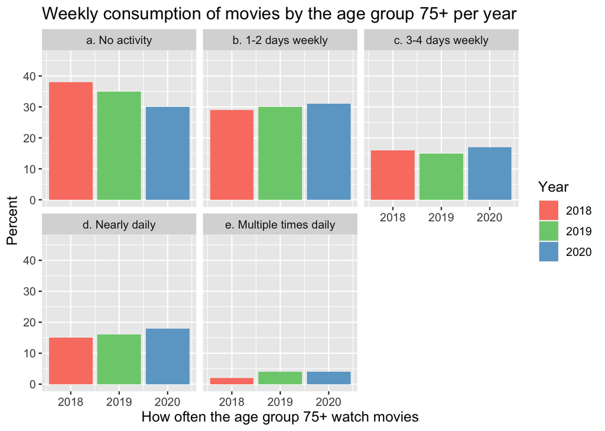

```r
age_movies %>%
  ggplot(aes(x = year, y = movies_75_over, fill = as.factor(year))) +
  geom_bar(stat = "identity", position = "dodge") +
  labs(title="Weekly consumption of movies by the age group 75+ per year",
       x="How often the age group 75+ watch movies",
       y="Percent") +
  theme(text = element_text(size = 12))+
  facet_wrap(~ age_movies$amount) +
  ylim(0,46) +
  scale_fill_manual('Year', values = c('salmon','palegreen3','skyblue3'))
```